# Oct 10–multiple data sheets

Julin Maloof

2023-10-08

## Intro

The goal is to import all of the size survey data sheets for the transplants into a single tibble. We will work through the commands and challenges of doing this

```r
library(tidyverse)
```

## Github

Let’s practice working with github. Go to your github account and create a new repository “UCD-2022-Transplant-Growth” (or something similar).

- Clone this to your computer and make sure Rstudio is set to use it as the working directory.
- Create folders inside of this repo `scripts`, `input`, and `output`.
- Unzip the `CorrectedCSVs.zip` file that Julin gave you into the `input` directory
- Create a new .Rmd script inside of scripts `DataImport.Rmd` or something similar.

## Get a list of files

Use code chunks in the `DataImport.Rmd` as we work through the rest of this.

You can get a list of files in a directory with the `dir` command. By default this lists files in the current working directory

```r
files <- dir()
files
```

```
## [1] "ANOVA_Tutorial.Rmd"                  "Day1Example.html"
## [3] "Day1Example.Rmd"                     "Oct_10_template_working_no_plot.Rmd"
## [5] "Oct_10_template_working.html"        "Oct_10_template_working.Rmd"
## [7] "Oct_10_template.Rmd"                 "Oct_10.Rmd"
## [9] "tidyverse_practice.Rmd"
```

You can specify a different directory by specifying the path

```r
files <- dir("../input/CorrectedCSVs/")
files
```

```
##  [1] "Annual_Census_Germination_20230522_corrected.csv"
##  [2] "Annual_census_germination_20230626_corrected.csv"
##  [3] "Annual_Census_Germination_All_May2023_corrected.csv"
##  [4] "Annual_Census_Transplants_20230522_corrected.csv"
##  [5] "Annual_Census_transplants_20230626_corrected.csv"
##  [6] "Annual_Census_Transplants_All_May_2023_corrected.csv"
##  [7] "Combined_mortality_size_survey_transplants_20230515_corrected.csv"
##  [8] "Combined_mortality_size_survey_transplants_20230515_corrected.gsheet"
##  [9] "Germination_survey_20230127_corrected.csv"
## [10] "Germination_survey_20230210_corrected.csv"
## [11] "Germination_survey_20230210_corrected.gsheet"
## [12] "Germination_survey_20230403_corrected.csv"
## [13] "Germination_survey_20230403_corrected.gsheet"
## [14] "Germination_survey_20230508_corrected.csv"
## [15] "Germination_survey_20230508_corrected.gsheet"
```

[output cut: 74 more lines]

You can specify what files you want using the pattern argument. Modify the code below so that you only retrieve size survey transplant csv files. You will need to use the *regex* method of specifying wildcards:

```r
files <- dir("../input/CorrectedCSVs",
             pattern="Size_survey_transplants.*corrected.*csv")
files
```

```
##  [1] "Size_survey_transplants_20230127_corrected.csv"
##  [2] "Size_survey_transplants_20230217_corrected.csv"
##  [3] "Size_survey_transplants_20230303_corrected.csv"
##  [4] "Size_survey_transplants_20230317_corrected.csv"
##  [5] "Size_survey_transplants_20230324_corrected.csv"
##  [6] "Size_survey_transplants_20230403_corrected.csv"
##  [7] "Size_survey_transplants_20230410_corrected.csv"
##  [8] "Size_survey_transplants_20230417_corrected.csv"
##  [9] "Size_survey_transplants_20230424_corrected.csv"
## [10] "Size_survey_transplants_20230501_corrected.csv"
## [11] "Size_survey_transplants_20230508_corrected.csv"
## [12] "Size_survey_transplants_20230605_corrected.csv"
## [13] "Size_survey_transplants_20230703_corrected.csv"
## [14] "Size_survey_transplants_20230710_corrected.csv"
## [15] "Size_survey_transplants_20230717_corrected.csv"
## [16] "Size_survey_transplants_20230724_corrected.csv"
```

Finally, when can specify `full.names=TRUE` to get the full path, which we will need later on

```r
files <- dir("../input/CorrectedCSVs/",
             pattern="Size_survey_transplants.*corrected.*csv",
             full.names=TRUE)
files
```

```
##  [1] "../input/CorrectedCSVs//Size_survey_transplants_20230127_corrected.csv"
##  [2] "../input/CorrectedCSVs//Size_survey_transplants_20230217_corrected.csv"
##  [3] "../input/CorrectedCSVs//Size_survey_transplants_20230303_corrected.csv"
##  [4] "../input/CorrectedCSVs//Size_survey_transplants_20230317_corrected.csv"
##  [5] "../input/CorrectedCSVs//Size_survey_transplants_20230324_corrected.csv"
##  [6] "../input/CorrectedCSVs//Size_survey_transplants_20230403_corrected.csv"
##  [7] "../input/CorrectedCSVs//Size_survey_transplants_20230410_corrected.csv"
##  [8] "../input/CorrectedCSVs//Size_survey_transplants_20230417_corrected.csv"
##  [9] "../input/CorrectedCSVs//Size_survey_transplants_20230424_corrected.csv"
## [10] "../input/CorrectedCSVs//Size_survey_transplants_20230501_corrected.csv"
## [11] "../input/CorrectedCSVs//Size_survey_transplants_20230508_corrected.csv"
## [12] "../input/CorrectedCSVs//Size_survey_transplants_20230605_corrected.csv"
## [13] "../input/CorrectedCSVs//Size_survey_transplants_20230703_corrected.csv"
## [14] "../input/CorrectedCSVs//Size_survey_transplants_20230710_corrected.csv"
## [15] "../input/CorrectedCSVs//Size_survey_transplants_20230717_corrected.csv"
## [16] "../input/CorrectedCSVs//Size_survey_transplants_20230724_corrected.csv"
```

## Create a tibble to hold the imported data

We will use a tibble to hold our imported data. We will start by creating a column with the full pathname and the file name:

```r
dat <- tibble(path=files, filename=basename(path))
dat
```

```
## # A tibble: 16 × 2
##    path                                                                  filen…¹
##    <chr>                                                                 <chr>
##  1 ../input/CorrectedCSVs//Size_survey_transplants_20230127_corrected.c… Size_s…
##  2 ../input/CorrectedCSVs//Size_survey_transplants_20230217_corrected.c… Size_s…
##  3 ../input/CorrectedCSVs//Size_survey_transplants_20230303_corrected.c… Size_s…
##  4 ../input/CorrectedCSVs//Size_survey_transplants_20230317_corrected.c… Size_s…
##  5 ../input/CorrectedCSVs//Size_survey_transplants_20230324_corrected.c… Size_s…
##  6 ../input/CorrectedCSVs//Size_survey_transplants_20230403_corrected.c… Size_s…
##  7 ../input/CorrectedCSVs//Size_survey_transplants_20230410_corrected.c… Size_s…
##  8 ../input/CorrectedCSVs//Size_survey_transplants_20230417_corrected.c… Size_s…
##  9 ../input/CorrectedCSVs//Size_survey_transplants_20230424_corrected.c… Size_s…
## 10 ../input/CorrectedCSVs//Size_survey_transplants_20230501_corrected.c… Size_s…
## 11 ../input/CorrectedCSVs//Size_survey_transplants_20230508_corrected.c… Size_s…
## 12 ../input/CorrectedCSVs//Size_survey_transplants_20230605_corrected.c… Size_s…
## 13 ../input/CorrectedCSVs//Size_survey_transplants_20230703_corrected.c… Size_s…
## 14 ../input/CorrectedCSVs//Size_survey_transplants_20230710_corrected.c… Size_s…
## 15 ../input/CorrectedCSVs//Size_survey_transplants_20230717_corrected.c… Size_s…
## 16 ../input/CorrectedCSVs//Size_survey_transplants_20230724_corrected.c… Size_s…
## # … with abbreviated variable name ¹filename
```

What did the `basename` function do?

Next, use what you learned in the regex tutorial to create a new column “survey_date”, extracted from the filename

```r
# create a new column, "date"
dat <- dat %>%
  mutate(survey_date=str_extract(filename, "2[0-9]*"),
         survey_date=lubridate::ymd(survey_date))
dat
```

```
## # A tibble: 16 × 3
##    path                                                       filen…¹ survey_d…²
##    <chr>                                                      <chr>   <date>
##  1 ../input/CorrectedCSVs//Size_survey_transplants_20230127_… Size_s… 2023-01-27
##  2 ../input/CorrectedCSVs//Size_survey_transplants_20230217_… Size_s… 2023-02-17
##  3 ../input/CorrectedCSVs//Size_survey_transplants_20230303_… Size_s… 2023-03-03
##  4 ../input/CorrectedCSVs//Size_survey_transplants_20230317_… Size_s… 2023-03-17
##  5 ../input/CorrectedCSVs//Size_survey_transplants_20230324_… Size_s… 2023-03-24
##  6 ../input/CorrectedCSVs//Size_survey_transplants_20230403_… Size_s… 2023-04-03
##  7 ../input/CorrectedCSVs//Size_survey_transplants_20230410_… Size_s… 2023-04-10
##  8 ../input/CorrectedCSVs//Size_survey_transplants_20230417_… Size_s… 2023-04-17
##  9 ../input/CorrectedCSVs//Size_survey_transplants_20230424_… Size_s… 2023-04-24
## 10 ../input/CorrectedCSVs//Size_survey_transplants_20230501_… Size_s… 2023-05-01
## 11 ../input/CorrectedCSVs//Size_survey_transplants_20230508_… Size_s… 2023-05-08
## 12 ../input/CorrectedCSVs//Size_survey_transplants_20230605_… Size_s… 2023-06-05
## 13 ../input/CorrectedCSVs//Size_survey_transplants_20230703_… Size_s… 2023-07-03
## 14 ../input/CorrectedCSVs//Size_survey_transplants_20230710_… Size_s… 2023-07-10
## 15 ../input/CorrectedCSVs//Size_survey_transplants_20230717_… Size_s… 2023-07-17
## 16 ../input/CorrectedCSVs//Size_survey_transplants_20230724_… Size_s… 2023-07-24
## # … with abbreviated variable names ¹filename, ²survey_date
```

Once you have the date column, we can tell R to use it as a date with the `ymd` function. (Note there are other variants as well…)

```r
dat <- dat %>%
  mutate(survey_date=lubridate::ymd(survey_date))
dat
```

```
## # A tibble: 16 × 3
##    path                                                       filen…¹ survey_d…²
##    <chr>                                                      <chr>   <date>
##  1 ../input/CorrectedCSVs//Size_survey_transplants_20230127_… Size_s… 2023-01-27
##  2 ../input/CorrectedCSVs//Size_survey_transplants_20230217_… Size_s… 2023-02-17
##  3 ../input/CorrectedCSVs//Size_survey_transplants_20230303_… Size_s… 2023-03-03
##  4 ../input/CorrectedCSVs//Size_survey_transplants_20230317_… Size_s… 2023-03-17
##  5 ../input/CorrectedCSVs//Size_survey_transplants_20230324_… Size_s… 2023-03-24
##  6 ../input/CorrectedCSVs//Size_survey_transplants_20230403_… Size_s… 2023-04-03
##  7 ../input/CorrectedCSVs//Size_survey_transplants_20230410_… Size_s… 2023-04-10
##  8 ../input/CorrectedCSVs//Size_survey_transplants_20230417_… Size_s… 2023-04-17
##  9 ../input/CorrectedCSVs//Size_survey_transplants_20230424_… Size_s… 2023-04-24
## 10 ../input/CorrectedCSVs//Size_survey_transplants_20230501_… Size_s… 2023-05-01
## 11 ../input/CorrectedCSVs//Size_survey_transplants_20230508_… Size_s… 2023-05-08
## 12 ../input/CorrectedCSVs//Size_survey_transplants_20230605_… Size_s… 2023-06-05
## 13 ../input/CorrectedCSVs//Size_survey_transplants_20230703_… Size_s… 2023-07-03
## 14 ../input/CorrectedCSVs//Size_survey_transplants_20230710_… Size_s… 2023-07-10
## 15 ../input/CorrectedCSVs//Size_survey_transplants_20230717_… Size_s… 2023-07-17
## 16 ../input/CorrectedCSVs//Size_survey_transplants_20230724_… Size_s… 2023-07-24
## # … with abbreviated variable names ¹filename, ²survey_date
```

## Read in the files

As you know, we can use `read_csv` to read in csv files. We don’t want to have to type a separate `read_csv` command for each file that we want to read. Luckily there is a way to automate the process.

We will use the `map()` function to help us. `map` applies a function to each element of a list

Example:

```r
map(1:10, sum, 5)
```

```
## [[1]]
## [1] 6
##
## [[2]]
## [1] 7
##
## [[3]]
## [1] 8
##
## [[4]]
## [1] 9
##
## [[5]]
## [1] 10
##
## [[6]]
## [1] 11
##
## [[7]]
## [1] 12
##
## [[8]]
## [1] 13
##
## [[9]]
## [1] 14
##
## [[10]]
## [1] 15
```

What did the above code do?

So, to import:

```r
dat <- dat %>%
  mutate(sheets=map(path,
                    read_csv,
                    col_types=cols(.default=col_character()), # forces all columns to be character
                                                              # this is needed because of data sheet problems that cause some numerics to be imported as character
                    na = c("", "NA", "-") # sets NA strings.  Julin to explain in meeting.
                    )) %>%
  select(-path)
dat
```

```
## # A tibble: 16 × 3
##    filename                                       survey_date sheets
##    <chr>                                          <date>      <list>
##  1 Size_survey_transplants_20230127_corrected.csv 2023-01-27  <spc_tbl_>
##  2 Size_survey_transplants_20230217_corrected.csv 2023-02-17  <spc_tbl_>
##  3 Size_survey_transplants_20230303_corrected.csv 2023-03-03  <spc_tbl_>
##  4 Size_survey_transplants_20230317_corrected.csv 2023-03-17  <spc_tbl_>
##  5 Size_survey_transplants_20230324_corrected.csv 2023-03-24  <spc_tbl_>
##  6 Size_survey_transplants_20230403_corrected.csv 2023-04-03  <spc_tbl_>
##  7 Size_survey_transplants_20230410_corrected.csv 2023-04-10  <spc_tbl_>
##  8 Size_survey_transplants_20230417_corrected.csv 2023-04-17  <spc_tbl_>
##  9 Size_survey_transplants_20230424_corrected.csv 2023-04-24  <spc_tbl_>
## 10 Size_survey_transplants_20230501_corrected.csv 2023-05-01  <spc_tbl_>
## 11 Size_survey_transplants_20230508_corrected.csv 2023-05-08  <spc_tbl_>
## 12 Size_survey_transplants_20230605_corrected.csv 2023-06-05  <spc_tbl_>
## 13 Size_survey_transplants_20230703_corrected.csv 2023-07-03  <spc_tbl_>
## 14 Size_survey_transplants_20230710_corrected.csv 2023-07-10  <spc_tbl_>
## 15 Size_survey_transplants_20230717_corrected.csv 2023-07-17  <spc_tbl_>
## 16 Size_survey_transplants_20230724_corrected.csv 2023-07-24  <spc_tbl_>
```

Now we have a new column “sheets” and each element of sheets is one imported csv file. You can check this with:

```r
dat$sheets[[1]] # extract the first imported sheet.
```

```
## # A tibble: 897 × 10
##    block row   col   pop    mf    rep   `height (cm)` longest leaf…¹ Notes ...10
##    <chr> <chr> <chr> <chr>  <chr> <chr> <chr>         <chr>          <chr> <chr>
##  1 D1    1     A     buffer <NA>  <NA>  <NA>          <NA>           <NA>  <NA>
##  2 D1    1     B     buffer <NA>  <NA>  <NA>          <NA>           <NA>  <NA>
##  3 D1    2     A     buffer <NA>  <NA>  <NA>          <NA>           <NA>  <NA>
##  4 D1    2     B     buffer <NA>  <NA>  <NA>          <NA>           <NA>  <NA>
##  5 D1    3     A     WL2    4     11    1.3           0.9            <NA>  <NA>
##  6 D1    3     B     CP2    10    4     <NA>          <NA>           dead  <NA>
##  7 D1    4     A     YO11   4     10    <NA>          <NA>           dead  <NA>
##  8 D1    4     B     CC     5     12    3.7           2.4            <NA>  <NA>
##  9 D1    5     A     FR     3     6     4.1           3.6            <NA>  <NA>
## 10 D1    5     B     BH     5     24    3.9           4.2            <NA>  <NA>
## # … with 887 more rows, and abbreviated variable name ¹`longest leaf (cm)`
```

## Combine the data

We would like to get all of those datasheets combined into a single one. Before we do that we want to make sure that the column names are consistent. We can look at the column names by using map again:

```r
map(dat$sheets, colnames)
```

```
## [[1]]
##  [1] "block"             "row"               "col"
##  [4] "pop"               "mf"                "rep"
##  [7] "height (cm)"       "longest leaf (cm)" "Notes"
## [10] "...10"
##
## [[2]]
##  [1] "survey date"        "block"              "row"
##  [4] "col"                "pop"                "mf"
##  [7] "rep"                "height (cm)"        "longest leaf (cm)"
## [10] "herbivory (Y or N)" "Notes"
##
## [[3]]
##  [1] "block"              "row"                "col"
##  [4] "pop"                "mf"                 "rep"
##  [7] "height (cm)"        "longest leaf (cm)"  "herbivory (Y or N)"
## [10] "Notes"
##
## [[4]]
##  [1] "survey date"        "block"              "row"
##  [4] "col"                "pop"                "mf"
##  [7] "rep"                "height (cm)"        "longest leaf (cm)"
## [10] "herbivory (Y or N)" "Notes"
##
## [[5]]
##  [1] "survey date"        "block"              "row"
##  [4] "col"                "pop"                "mf"
##  [7] "rep"                "height (cm)"        "longest leaf (cm)"
## [10] "herbivory (Y or N)" "Notes"
##
## [[6]]
##  [1] "4/3/23"             "block"              "row"
##  [4] "col"                "pop"                "mf"
##  [7] "rep"                "height (cm)"        "longest leaf (cm)"
## [10] "herbivory (Y or N)" "Notes"
##
## [[7]]
##  [1] "survey date"        "block"              "row"
##  [4] "col"                "pop"                "mf"
##  [7] "rep"                "height (cm)"        "longest leaf (cm)"
```

[output cut: 40 more lines]

```
##  [4] "col"                "pop"                "mf"
##  [7] "rep"                "height (cm)"        "longest leaf (cm)"
## [10] "herbivory (Y or N)" "wilting status"     "Notes"
##
## [[15]]
##  [1] "survey date"        "block"              "row"
##  [4] "col"                "pop"                "mf"
##  [7] "rep"                "height (cm)"        "longest leaf (cm)"
## [10] "herbivory (Y or N)" "wilting status"     "Notes"
##
## [[16]]
##  [1] "survey date"        "block"              "row"
##  [4] "col"                "pop"                "mf"
##  [7] "rep"                "height (cm)"        "longest leaf (cm)"
## [10] "herbivory (Y or N)" "wilting status"     "Notes"
```

It could be useful to look at all of the unique column names

```r
map(dat$sheets, colnames) %>%
  unlist() %>%
  unique() %>%
  sort()
```

```
##  [1] "...10"              "...12"              "4/3/23"
##  [4] "block"              "col"                "date"
##  [7] "Date"               "height (cm)"        "herbivory (Y or N)"
## [10] "longest leaf (cm)"  "mf"                 "Notes"
## [13] "pop"                "rep"                "row"
## [16] "survey date"        "wilting status"
```

Next let’s take a look at the first 10 lines of each data sheet, again using `map`

```r
map(dat$sheets, head,10)
```

```
## [[1]]
## # A tibble: 10 × 10
##    block row   col   pop    mf    rep   `height (cm)` longest leaf…¹ Notes ...10
##    <chr> <chr> <chr> <chr>  <chr> <chr> <chr>         <chr>          <chr> <chr>
##  1 D1    1     A     buffer <NA>  <NA>  <NA>          <NA>           <NA>  <NA>
##  2 D1    1     B     buffer <NA>  <NA>  <NA>          <NA>           <NA>  <NA>
##  3 D1    2     A     buffer <NA>  <NA>  <NA>          <NA>           <NA>  <NA>
##  4 D1    2     B     buffer <NA>  <NA>  <NA>          <NA>           <NA>  <NA>
##  5 D1    3     A     WL2    4     11    1.3           0.9            <NA>  <NA>
##  6 D1    3     B     CP2    10    4     <NA>          <NA>           dead  <NA>
##  7 D1    4     A     YO11   4     10    <NA>          <NA>           dead  <NA>
##  8 D1    4     B     CC     5     12    3.7           2.4            <NA>  <NA>
##  9 D1    5     A     FR     3     6     4.1           3.6            <NA>  <NA>
## 10 D1    5     B     BH     5     24    3.9           4.2            <NA>  <NA>
## # … with abbreviated variable name ¹`longest leaf (cm)`
##
## [[2]]
## # A tibble: 10 × 11
##    survey da…¹ block row   col   pop   mf    rep   heigh…² longe…³ herbi…⁴ Notes
##    <chr>       <chr> <chr> <chr> <chr> <chr> <chr> <chr>   <chr>   <chr>   <chr>
##  1 2/17/23     D1    1     A     buff… <NA>  <NA>  <NA>    <NA>    <NA>    <NA>
##  2 2/17/23     D1    1     B     buff… <NA>  <NA>  <NA>    <NA>    <NA>    <NA>
##  3 2/17/23     D1    2     A     buff… <NA>  <NA>  <NA>    <NA>    <NA>    <NA>
##  4 2/17/23     D1    2     B     buff… <NA>  <NA>  <NA>    <NA>    <NA>    <NA>
##  5 2/17/23     D1    3     A     WL2   4     11    1.5     1.4     N       <NA>
##  6 2/17/23     D1    3     B     CP2   10    4     <NA>    <NA>    <NA>    Dead
##  7 2/17/23     D1    4     A     YO11  4     10    <NA>    <NA>    <NA>    Dead
##  8 2/17/23     D1    4     B     CC    5     12    3.4     1.5     N       <NA>
##  9 2/17/23     D1    5     A     FR    3     6     3.5     3       N       <NA>
## 10 2/17/23     D1    5     B     BH    5     24    4.3     2.5     N       <NA>
## # … with abbreviated variable names ¹`survey date`, ²`height (cm)`,
## #   ³`longest leaf (cm)`, ⁴`herbivory (Y or N)`
##
## [[3]]
## # A tibble: 10 × 10
##    block row   col   pop    mf    rep   `height (cm)` longest le…¹ herbi…² Notes
##    <chr> <chr> <chr> <chr>  <chr> <chr> <chr>         <chr>        <chr>   <chr>
##  1 D1    1     A     buffer <NA>  <NA>  <NA>          <NA>         <NA>    <NA>
##  2 D1    1     B     buffer <NA>  <NA>  <NA>          <NA>         <NA>    <NA>
##  3 D1    2     A     buffer <NA>  <NA>  <NA>          <NA>         <NA>    <NA>
```

[output cut: 221 more lines]

```
##    survey …¹ block row   col   pop   mf    rep   heigh…² longe…³ herbi…⁴ wilti…⁵
##    <chr>     <chr> <chr> <chr> <chr> <chr> <chr> <chr>   <chr>   <chr>   <chr>
##  1 7/24/23   D1    1     A     buff… <NA>  <NA>  <NA>    <NA>    <NA>    <NA>
##  2 7/24/23   D1    1     B     buff… <NA>  <NA>  <NA>    <NA>    <NA>    <NA>
##  3 7/24/23   D1    2     A     buff… <NA>  <NA>  <NA>    <NA>    <NA>    <NA>
##  4 7/24/23   D1    2     B     buff… <NA>  <NA>  <NA>    <NA>    <NA>    <NA>
##  5 7/24/23   D1    3     A     WL2   4     11    <NA>    <NA>    <NA>    <NA>
##  6 7/24/23   D1    3     B     CP2   10    4     <NA>    <NA>    <NA>    <NA>
##  7 7/24/23   D1    4     A     YO11  4     10    <NA>    <NA>    <NA>    <NA>
##  8 7/24/23   D1    4     B     CC    5     12    <NA>    <NA>    <NA>    <NA>
##  9 7/24/23   D1    5     A     FR    3     6     <NA>    <NA>    <NA>    <NA>
## 10 7/24/23   D1    5     B     BH    5     24    <NA>    <NA>    <NA>    <NA>
## # … with 1 more variable: Notes <chr>, and abbreviated variable names
## #   ¹`survey date`, ²`height (cm)`, ³`longest leaf (cm)`,
## #   ⁴`herbivory (Y or N)`, ⁵`wilting status`
```

Any issues? (will discuss in live meeting)

Now let’s combine the data. The `unnest()` function will attempt to combine all of the individual data frames into one. While we are at it, let’s rename a couple of the columns for convenience:

```r
dat <- dat %>% unnest(sheets) %>%
  rename(height_cm = `height (cm)`, longest_leaf_cm = `longest leaf (cm)`)
dat
```

```
## # A tibble: 13,962 × 19
##    filename survey_d…¹ block row   col   pop   mf    rep   heigh…² longe…³ Notes
##    <chr>    <date>     <chr> <chr> <chr> <chr> <chr> <chr> <chr>   <chr>   <chr>
##  1 Size_su… 2023-01-27 D1    1     A     buff… <NA>  <NA>  <NA>    <NA>    <NA>
##  2 Size_su… 2023-01-27 D1    1     B     buff… <NA>  <NA>  <NA>    <NA>    <NA>
##  3 Size_su… 2023-01-27 D1    2     A     buff… <NA>  <NA>  <NA>    <NA>    <NA>
##  4 Size_su… 2023-01-27 D1    2     B     buff… <NA>  <NA>  <NA>    <NA>    <NA>
##  5 Size_su… 2023-01-27 D1    3     A     WL2   4     11    1.3     0.9     <NA>
##  6 Size_su… 2023-01-27 D1    3     B     CP2   10    4     <NA>    <NA>    dead
##  7 Size_su… 2023-01-27 D1    4     A     YO11  4     10    <NA>    <NA>    dead
##  8 Size_su… 2023-01-27 D1    4     B     CC    5     12    3.7     2.4     <NA>
##  9 Size_su… 2023-01-27 D1    5     A     FR    3     6     4.1     3.6     <NA>
## 10 Size_su… 2023-01-27 D1    5     B     BH    5     24    3.9     4.2     <NA>
## # … with 13,952 more rows, 8 more variables: ...10 <chr>, `survey date` <chr>,
## #   `herbivory (Y or N)` <chr>, `4/3/23` <chr>, Date <chr>, ...12 <chr>,
## #   date <chr>, `wilting status` <chr>, and abbreviated variable names
## #   ¹survey_date, ²height_cm, ³longest_leaf_cm
```

What are columns …10 and …12?

```r
dat %>% filter(!is.na(...10) | !is.na(...12))
```

```
## # A tibble: 1 × 19
##   filename  survey_d…¹ block row   col   pop   mf    rep   heigh…² longe…³ Notes
##   <chr>     <date>     <chr> <chr> <chr> <chr> <chr> <chr> <chr>   <chr>   <chr>
## 1 Size_sur… 2023-01-27 L1    17    B     FR    2     1     1.7     1.7     wilt…
## # … with 8 more variables: ...10 <chr>, `survey date` <chr>,
## #   `herbivory (Y or N)` <chr>, `4/3/23` <chr>, Date <chr>, ...12 <chr>,
## #   date <chr>, `wilting status` <chr>, and abbreviated variable names
## #   ¹survey_date, ²height_cm, ³longest_leaf_cm
```

nothing to worry about

## Fix the data problems

OK, row should be numeric, but isn’t. Let’s see why not

This code goes row-by-row and keeps the rows where `row` cannot be coverted to numeric.

```r
dat %>% rowwise() %>% filter(is.na(as.numeric(row)))
```

```
## # A tibble: 234 × 19
## # Rowwise:
##    filename survey_d…¹ block row   col   pop   mf    rep   heigh…² longe…³ Notes
##    <chr>    <date>     <chr> <chr> <chr> <chr> <chr> <chr> <chr>   <chr>   <chr>
##  1 Size_su… 2023-01-27 block row   col   pop   mf    rep   height… longes… Notes
##  2 Size_su… 2023-01-27 block row   col   pop   mf    rep   height… longes… Notes
##  3 Size_su… 2023-01-27 block row   col   pop   mf    rep   height… longes… Notes
##  4 Size_su… 2023-01-27 block row   col   pop   mf    rep   height… longes… Notes
##  5 Size_su… 2023-01-27 block row   col   pop   mf    rep   height… longes… Notes
##  6 Size_su… 2023-01-27 block row   col   pop   mf    rep   height… longes… Notes
##  7 Size_su… 2023-01-27 block row   col   pop   mf    rep   height… longes… Notes
##  8 Size_su… 2023-01-27 block row   col   pop   mf    rep   height… longes… Notes
##  9 Size_su… 2023-01-27 block row   col   pop   mf    rep   height… longes… Notes
## 10 Size_su… 2023-01-27 block row   col   pop   mf    rep   height… longes… Notes
## # … with 224 more rows, 8 more variables: ...10 <chr>, `survey date` <chr>,
## #   `herbivory (Y or N)` <chr>, `4/3/23` <chr>, Date <chr>, ...12 <chr>,
## #   date <chr>, `wilting status` <chr>, and abbreviated variable names
## #   ¹survey_date, ²height_cm, ³longest_leaf_cm
```

What is the problem?

What is the fix?

```r
dat <- dat %>% filter(block!="block")
```

```r
dat %>% rowwise() %>% filter(is.na(as.numeric(row)))
```

```
## # A tibble: 0 × 19
## # Rowwise:
## # … with 19 variables: filename <chr>, survey_date <date>, block <chr>,
## #   row <chr>, col <chr>, pop <chr>, mf <chr>, rep <chr>, height_cm <chr>,
## #   longest_leaf_cm <chr>, Notes <chr>, ...10 <chr>, survey date <chr>,
## #   herbivory (Y or N) <chr>, 4/3/23 <chr>, Date <chr>, ...12 <chr>,
## #   date <chr>, wilting status <chr>
```

Next steps: check the other columns that should be numeric, and fix if needed.

```r
dat %>% rowwise() %>% filter(is.na(as.numeric(mf)))
```

```
## # A tibble: 1,618 × 19
## # Rowwise:
##    filename survey_d…¹ block row   col   pop   mf    rep   heigh…² longe…³ Notes
##    <chr>    <date>     <chr> <chr> <chr> <chr> <chr> <chr> <chr>   <chr>   <chr>
##  1 Size_su… 2023-01-27 D1    1     A     buff… <NA>  <NA>  <NA>    <NA>    <NA>
##  2 Size_su… 2023-01-27 D1    1     B     buff… <NA>  <NA>  <NA>    <NA>    <NA>
##  3 Size_su… 2023-01-27 D1    2     A     buff… <NA>  <NA>  <NA>    <NA>    <NA>
##  4 Size_su… 2023-01-27 D1    2     B     buff… <NA>  <NA>  <NA>    <NA>    <NA>
##  5 Size_su… 2023-01-27 D2    42    A     buff… <NA>  <NA>  <NA>    <NA>    <NA>
##  6 Size_su… 2023-01-27 D2    42    B     buff… <NA>  <NA>  <NA>    <NA>    <NA>
##  7 Size_su… 2023-01-27 D2    43    A     buff… <NA>  <NA>  <NA>    <NA>    <NA>
##  8 Size_su… 2023-01-27 D2    43    B     buff… <NA>  <NA>  <NA>    <NA>    <NA>
##  9 Size_su… 2023-01-27 D1    1     C     buff… <NA>  <NA>  <NA>    <NA>    <NA>
## 10 Size_su… 2023-01-27 D1    1     D     buff… <NA>  <NA>  <NA>    <NA>    <NA>
## # … with 1,608 more rows, 8 more variables: ...10 <chr>, `survey date` <chr>,
## #   `herbivory (Y or N)` <chr>, `4/3/23` <chr>, Date <chr>, ...12 <chr>,
## #   date <chr>, `wilting status` <chr>, and abbreviated variable names
## #   ¹survey_date, ²height_cm, ³longest_leaf_cm
```

get rid of buffers

```r
dat <- dat %>% filter(pop!="buffer")
```

```r
dat %>% rowwise() %>% filter(is.na(as.numeric(mf)))
```

```
## # A tibble: 2 × 19
## # Rowwise:
##   filename  survey_d…¹ block row   col   pop   mf    rep   heigh…² longe…³ Notes
##   <chr>     <date>     <chr> <chr> <chr> <chr> <chr> <chr> <chr>   <chr>   <chr>
## 1 Size_sur… 2023-07-17 L2    42    C     BH    <NA>  <NA>  <NA>    <NA>    <NA>
## 2 Size_sur… 2023-07-17 L2    42    D     IH    <NA>  <NA>  <NA>    <NA>    <NA>
## # … with 8 more variables: ...10 <chr>, `survey date` <chr>,
## #   `herbivory (Y or N)` <chr>, `4/3/23` <chr>, Date <chr>, ...12 <chr>,
## #   date <chr>, `wilting status` <chr>, and abbreviated variable names
## #   ¹survey_date, ²height_cm, ³longest_leaf_cm
```

Why no mf for these two entries? Doesn’t really matter since there is no data in those rows…

```r
dat %>% rowwise() %>% filter(is.na(as.numeric(rep)))
```

```
## # A tibble: 2 × 19
## # Rowwise:
##   filename  survey_d…¹ block row   col   pop   mf    rep   heigh…² longe…³ Notes
##   <chr>     <date>     <chr> <chr> <chr> <chr> <chr> <chr> <chr>   <chr>   <chr>
## 1 Size_sur… 2023-07-17 L2    42    C     BH    <NA>  <NA>  <NA>    <NA>    <NA>
## 2 Size_sur… 2023-07-17 L2    42    D     IH    <NA>  <NA>  <NA>    <NA>    <NA>
## # … with 8 more variables: ...10 <chr>, `survey date` <chr>,
## #   `herbivory (Y or N)` <chr>, `4/3/23` <chr>, Date <chr>, ...12 <chr>,
## #   date <chr>, `wilting status` <chr>, and abbreviated variable names
## #   ¹survey_date, ²height_cm, ³longest_leaf_cm
```

checking height

```r
dat %>% rowwise() %>% filter(is.na(as.numeric(height_cm)))
```

```
## # A tibble: 9,597 × 19
## # Rowwise:
##    filename survey_d…¹ block row   col   pop   mf    rep   heigh…² longe…³ Notes
##    <chr>    <date>     <chr> <chr> <chr> <chr> <chr> <chr> <chr>   <chr>   <chr>
##  1 Size_su… 2023-01-27 D1    3     B     CP2   10    4     <NA>    <NA>    dead
##  2 Size_su… 2023-01-27 D1    4     A     YO11  4     10    <NA>    <NA>    dead
##  3 Size_su… 2023-01-27 D1    16    A     WL1   7     1     <NA>    <NA>    Dead
##  4 Size_su… 2023-01-27 D2    22    A     CP2   9     2     <NA>    <NA>    Dead
##  5 Size_su… 2023-01-27 D2    23    A     YO11  3     12    <NA>    <NA>    Dead
##  6 Size_su… 2023-01-27 D2    27    A     SQ2   4     6     <NA>    <NA>    Dead
##  7 Size_su… 2023-01-27 D2    28    A     LV3   8     7     <NA>    <NA>    Dead
##  8 Size_su… 2023-01-27 D2    31    A     WL2   1     7     <NA>    <NA>    Dead
##  9 Size_su… 2023-01-27 D2    33    A     WL1   2     11    <NA>    <NA>    Dead
## 10 Size_su… 2023-01-27 D2    36    A     YO8   2     2     <NA>    <NA>    Dead
## # … with 9,587 more rows, 8 more variables: ...10 <chr>, `survey date` <chr>,
## #   `herbivory (Y or N)` <chr>, `4/3/23` <chr>, Date <chr>, ...12 <chr>,
## #   date <chr>, `wilting status` <chr>, and abbreviated variable names
## #   ¹survey_date, ²height_cm, ³longest_leaf_cm
```

This gives us any row with an NA. What we really want is rows that generate an NA on conversion to numeric, so…

```r
dat %>% rowwise() %>% filter(!is.na(height_cm), is.na(as.numeric(height_cm)))
```

```
## # A tibble: 5 × 19
## # Rowwise:
##   filename  survey_d…¹ block row   col   pop   mf    rep   heigh…² longe…³ Notes
##   <chr>     <date>     <chr> <chr> <chr> <chr> <chr> <chr> <chr>   <chr>   <chr>
## 1 Size_sur… 2023-03-03 J2    35    A     LV3   7     9     Jan-00  1.1     <NA>
## 2 Size_sur… 2023-03-17 J1    20    C     CP2   3     12    I.l     1       <NA>
## 3 Size_sur… 2023-03-17 L1    12    A     WL2   4     9     3 . 1   1       <NA>
## 4 Size_sur… 2023-07-17 L2    40    D     BH    7     13    18. 1   5.1     <NA>
## 5 Size_sur… 2023-07-24 J2    29    A     IH    4     7     8. 1    2.1     <NA>
## # … with 8 more variables: ...10 <chr>, `survey date` <chr>,
## #   `herbivory (Y or N)` <chr>, `4/3/23` <chr>, Date <chr>, ...12 <chr>,
## #   date <chr>, `wilting status` <chr>, and abbreviated variable names
## #   ¹survey_date, ²height_cm, ³longest_leaf_cm
```

checking longest leaf

```r
dat %>% rowwise() %>% filter(!is.na(longest_leaf_cm), is.na(as.numeric(longest_leaf_cm)))
```

```
## # A tibble: 1 × 19
## # Rowwise:
##   filename  survey_d…¹ block row   col   pop   mf    rep   heigh…² longe…³ Notes
##   <chr>     <date>     <chr> <chr> <chr> <chr> <chr> <chr> <chr>   <chr>   <chr>
## 1 Size_sur… 2023-02-17 H1    16    C     CP2   10    2     1.6     1.80$   <NA>
## # … with 8 more variables: ...10 <chr>, `survey date` <chr>,
## #   `herbivory (Y or N)` <chr>, `4/3/23` <chr>, Date <chr>, ...12 <chr>,
## #   date <chr>, `wilting status` <chr>, and abbreviated variable names
## #   ¹survey_date, ²height_cm, ³longest_leaf_cm
```

ignoring the issues

```r
dat2 <- dat %>%
  mutate(across(c(longest_leaf_cm, height_cm), as.numeric))
```

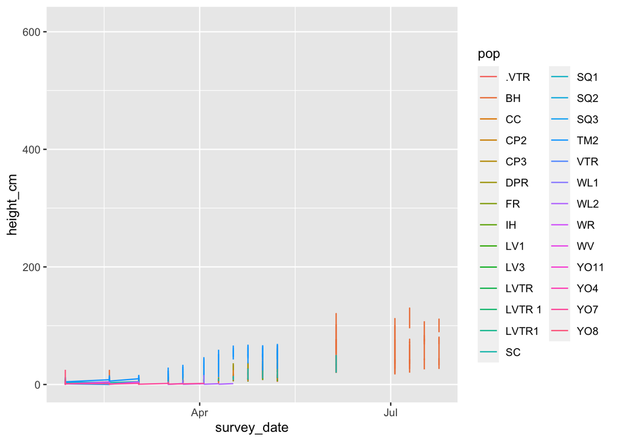

```r
dat2 %>%
  ggplot(aes(x=survey_date, y=height_cm, col=pop)) +
  geom_line()
```

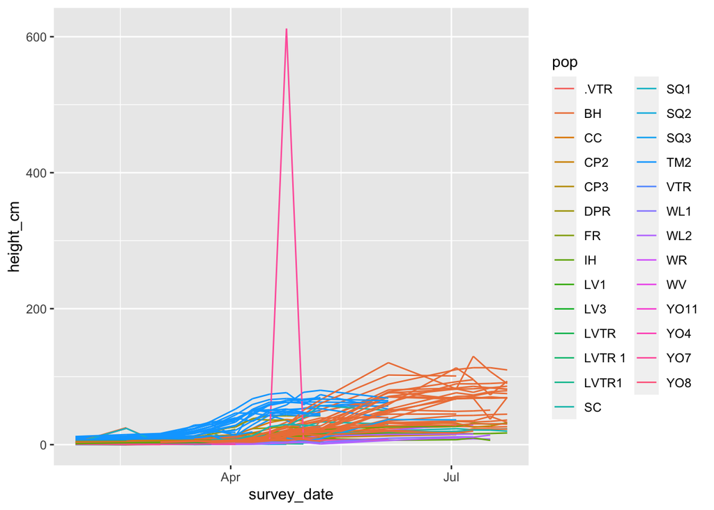

```r
dat2 %>% mutate(plantID=str_c(block,row,col)) %>%
  ggplot(aes(x=survey_date, y=height_cm, col=pop, group=plantID)) +
  geom_line()
```

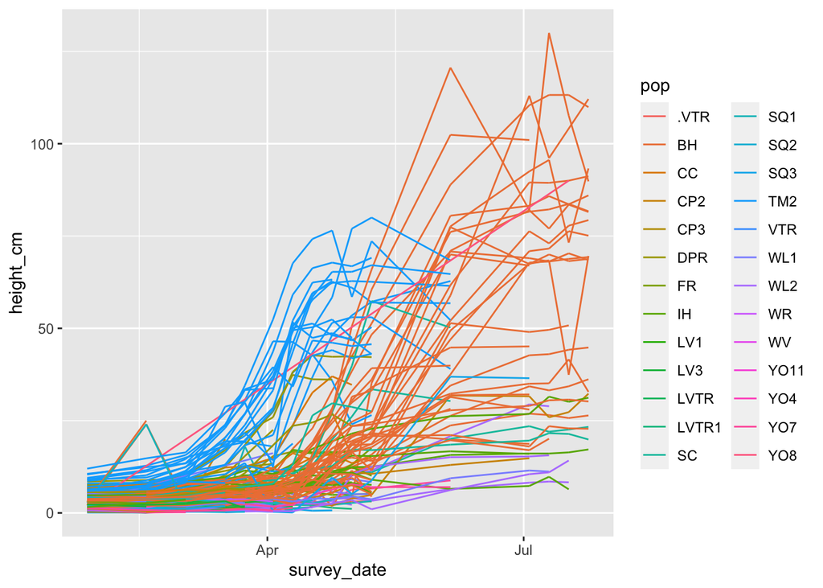

```r
dat2 %>% mutate(plantID=str_c(block,row,col)) %>%
  filter(height_cm < 200) %>%
  ggplot(aes(x=survey_date, y=height_cm, col=pop, group=plantID)) +
  geom_line()
```

```
## `geom_line()`: Each group consists of only one observation.
## ℹ Do you need to adjust the group aesthetic?
## `geom_line()`: Each group consists of only one observation.
## ℹ Do you need to adjust the group aesthetic?
## `geom_line()`: Each group consists of only one observation.
## ℹ Do you need to adjust the group aesthetic?
## `geom_line()`: Each group consists of only one observation.
## ℹ Do you need to adjust the group aesthetic?
## `geom_line()`: Each group consists of only one observation.
## ℹ Do you need to adjust the group aesthetic?
```

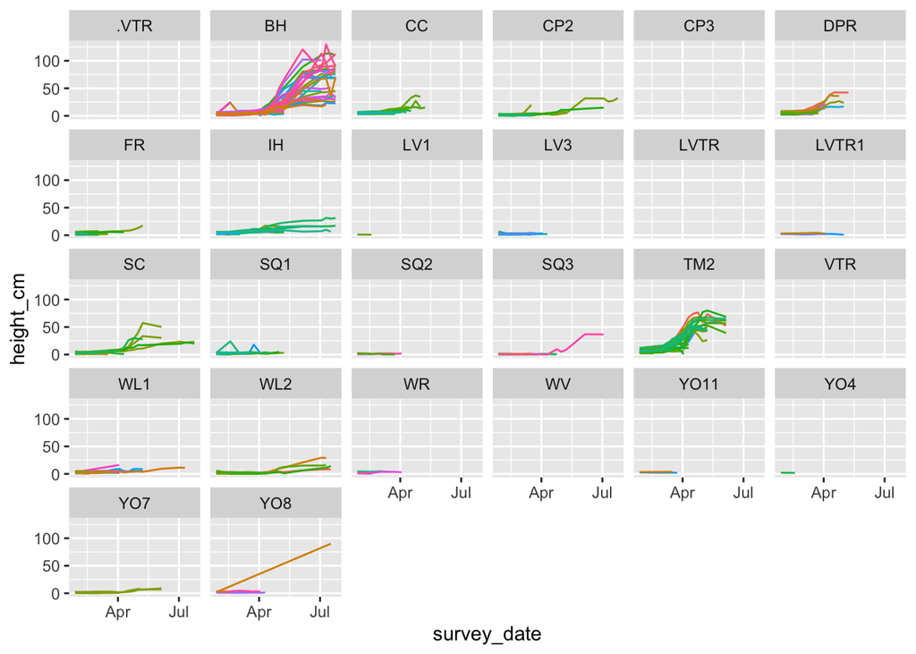

```r
dat2 %>% mutate(plantID=str_c(block,row,col)) %>%
  group_by(pop) %>%
  mutate(plantID2 = as.character(as.numeric(factor(plantID)))) %>%
  filter(height_cm < 200) %>%
  ggplot(aes(x=survey_date, y=height_cm, col=plantID2, group=plantID)) +
  geom_line(show.legend = FALSE) +
  facet_wrap(~pop)
```

What is up with YO8?

```r
dat2 %>% filter(pop=="YO8", !is.na(height_cm)) %>% arrange(block, row, col, height_cm)
```

```
## # A tibble: 25 × 19
##    filename survey_d…¹ block row   col   pop   mf    rep   heigh…² longe…³ Notes
##    <chr>    <date>     <chr> <chr> <chr> <chr> <chr> <chr>   <dbl>   <dbl> <chr>
##  1 Size_su… 2023-01-27 D1    20    D     YO8   3     12        0.4     0.3 <NA>
##  2 Size_su… 2023-01-27 F2    25    A     YO8   1     10        4.5     2.9 herb…
##  3 Size_su… 2023-02-17 H1    12    A     YO8   3     5         2.6     2.6 <NA>
##  4 Size_su… 2023-01-27 H1    12    A     YO8   3     5         3.2     2.5 herb…
##  5 Size_su… 2023-03-03 H1    12    A     YO8   3     5         3.2     1.1 <NA>
##  6 Size_su… 2023-03-17 H1    12    A     YO8   3     5         4       2.3 <NA>
##  7 Size_su… 2023-03-03 H2    31    B     YO8   3     6         0.7     1.1 <NA>
##  8 Size_su… 2023-04-03 H2    31    B     YO8   3     6         0.7     1.6 <NA>
##  9 Size_su… 2023-01-27 H2    31    B     YO8   3     6         1       0.6 <NA>
## 10 Size_su… 2023-02-17 H2    31    B     YO8   3     6         1       0.8 <NA>
## # … with 15 more rows, 8 more variables: ...10 <chr>, `survey date` <chr>,
## #   `herbivory (Y or N)` <chr>, `4/3/23` <chr>, Date <chr>, ...12 <chr>,
## #   date <chr>, `wilting status` <chr>, and abbreviated variable names
## #   ¹survey_date, ²height_cm, ³longest_leaf_cm
```

```r
dat2 %>% mutate(plantID=str_c(block,row,col)) %>% filter(plantID=="L113C")
```

```
## # A tibble: 16 × 20
##    filename survey_d…¹ block row   col   pop   mf    rep   heigh…² longe…³ Notes
##    <chr>    <date>     <chr> <chr> <chr> <chr> <chr> <chr>   <dbl>   <dbl> <chr>
##  1 Size_su… 2023-01-27 L1    13    C     BH    3     13        2.4     2.8 <NA>
##  2 Size_su… 2023-02-17 L1    13    C     BH    3     13        2.2     5.2 <NA>
##  3 Size_su… 2023-03-03 L1    13    C     BH    3     13        2.4     5.9 <NA>
##  4 Size_su… 2023-03-17 L1    13    C     BH    3     13        3.6     7.6 <NA>
##  5 Size_su… 2023-03-24 L1    13    C     BH    3     13        2.8     5.5 <NA>
##  6 Size_su… 2023-04-03 L1    13    C     BH    3     13        3.6     7.2 <NA>
##  7 Size_su… 2023-04-10 L1    13    C     BH    3     13        2.5     7.4 <NA>
##  8 Size_su… 2023-04-17 L1    13    C     BH    3     13       16       8.8 <NA>
##  9 Size_su… 2023-04-24 L1    13    C     BH    3     13       27.7     7.7 <NA>
## 10 Size_su… 2023-05-01 L1    13    C     BH    3     13       50.6     8.4 <NA>
## 11 Size_su… 2023-05-08 L1    13    C     BH    3     13       65.9     6.3 <NA>
## 12 Size_su… 2023-06-05 L1    13    C     BH    3     13      121.      7.7 <NA>
## 13 Size_su… 2023-07-03 L1    13    C     BH    3     13       82       7.8 <NA>
## 14 Size_su… 2023-07-10 L1    13    C     BH    3     13      130       7.9 <NA>
## 15 Size_su… 2023-07-17 L1    13    C     BH    3     13      108.      8.5 <NA>
## 16 Size_su… 2023-07-24 L1    13    C     BH    3     13       89.8     8.9 <NA>
## # … with 9 more variables: ...10 <chr>, `survey date` <chr>,
## #   `herbivory (Y or N)` <chr>, `4/3/23` <chr>, Date <chr>, ...12 <chr>,
## #   date <chr>, `wilting status` <chr>, plantID <chr>, and abbreviated variable
## #   names ¹survey_date, ²height_cm, ³longest_leaf_cm
```

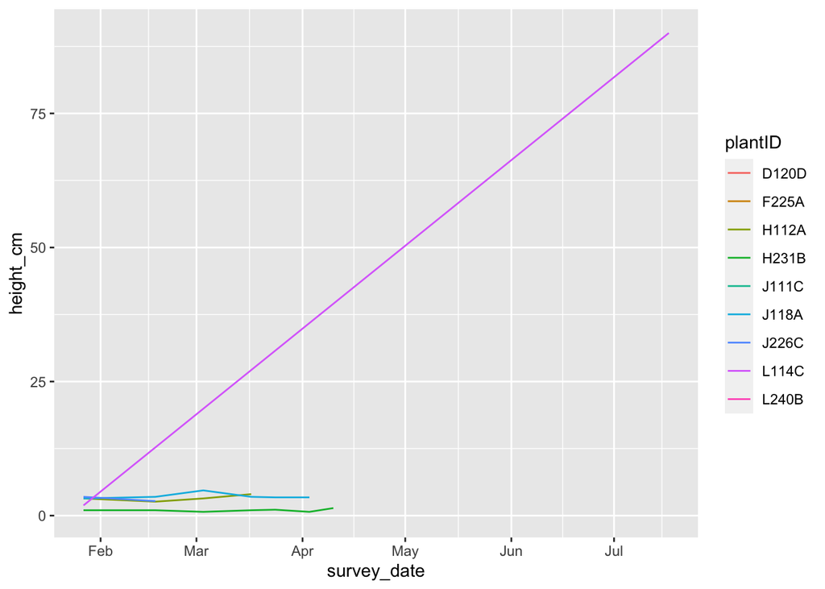

```r
dat2 %>% filter(pop=="YO8", !is.na(height_cm)) %>%
  mutate(plantID=str_c(block,row,col)) %>%
    ggplot(aes(x=survey_date, y=height_cm, col=plantID, group=plantID)) +
  geom_line()
```

```r
dat2 %>% filter( ! (pop=="YO8" & height_cm ==90))
```

```
## # A tibble: 11,928 × 19
##    filename survey_d…¹ block row   col   pop   mf    rep   heigh…² longe…³ Notes
##    <chr>    <date>     <chr> <chr> <chr> <chr> <chr> <chr>   <dbl>   <dbl> <chr>
##  1 Size_su… 2023-01-27 D1    3     A     WL2   4     11        1.3     0.9 <NA>
##  2 Size_su… 2023-01-27 D1    3     B     CP2   10    4        NA      NA   dead
##  3 Size_su… 2023-01-27 D1    4     A     YO11  4     10       NA      NA   dead
##  4 Size_su… 2023-01-27 D1    4     B     CC    5     12        3.7     2.4 <NA>
##  5 Size_su… 2023-01-27 D1    5     A     FR    3     6         4.1     3.6 <NA>
##  6 Size_su… 2023-01-27 D1    5     B     BH    5     24        3.9     4.2 <NA>
##  7 Size_su… 2023-01-27 D1    6     A     IH    6     12        3.5     4.5 <NA>
##  8 Size_su… 2023-01-27 D1    6     B     CC    3     10        2.3     1.6 <NA>
##  9 Size_su… 2023-01-27 D1    7     A     WL2   1     9         1.7     1.6 <NA>
## 10 Size_su… 2023-01-27 D1    7     B     CP2   8     4         0.5     1.2 herb…
## # … with 11,918 more rows, 8 more variables: ...10 <chr>, `survey date` <chr>,
## #   `herbivory (Y or N)` <chr>, `4/3/23` <chr>, Date <chr>, ...12 <chr>,
## #   date <chr>, `wilting status` <chr>, and abbreviated variable names
## #   ¹survey_date, ²height_cm, ³longest_leaf_cm
```

```r
dat2
```

```
## # A tibble: 12,112 × 19
##    filename survey_d…¹ block row   col   pop   mf    rep   heigh…² longe…³ Notes
##    <chr>    <date>     <chr> <chr> <chr> <chr> <chr> <chr>   <dbl>   <dbl> <chr>
##  1 Size_su… 2023-01-27 D1    3     A     WL2   4     11        1.3     0.9 <NA>
##  2 Size_su… 2023-01-27 D1    3     B     CP2   10    4        NA      NA   dead
##  3 Size_su… 2023-01-27 D1    4     A     YO11  4     10       NA      NA   dead
##  4 Size_su… 2023-01-27 D1    4     B     CC    5     12        3.7     2.4 <NA>
##  5 Size_su… 2023-01-27 D1    5     A     FR    3     6         4.1     3.6 <NA>
##  6 Size_su… 2023-01-27 D1    5     B     BH    5     24        3.9     4.2 <NA>
##  7 Size_su… 2023-01-27 D1    6     A     IH    6     12        3.5     4.5 <NA>
##  8 Size_su… 2023-01-27 D1    6     B     CC    3     10        2.3     1.6 <NA>
##  9 Size_su… 2023-01-27 D1    7     A     WL2   1     9         1.7     1.6 <NA>
## 10 Size_su… 2023-01-27 D1    7     B     CP2   8     4         0.5     1.2 herb…
## # … with 12,102 more rows, 8 more variables: ...10 <chr>, `survey date` <chr>,
## #   `herbivory (Y or N)` <chr>, `4/3/23` <chr>, Date <chr>, ...12 <chr>,
## #   date <chr>, `wilting status` <chr>, and abbreviated variable names
## #   ¹survey_date, ²height_cm, ³longest_leaf_cm
```